# Module R’Stat1 : Les modèles linéaires généralisés (GLM)

francois.rebaudo@ird.fr

Novembre 2019 ; IRD-Montpellier-France CC BY-NC-ND 3.0

# Rappels sur le modèle linéaire

## diapo de [S. Ballesteros, ENS](http://rug.mnhn.fr/semin-r/PDF/semin-R_glm_SBallesteros_100608.pdf)

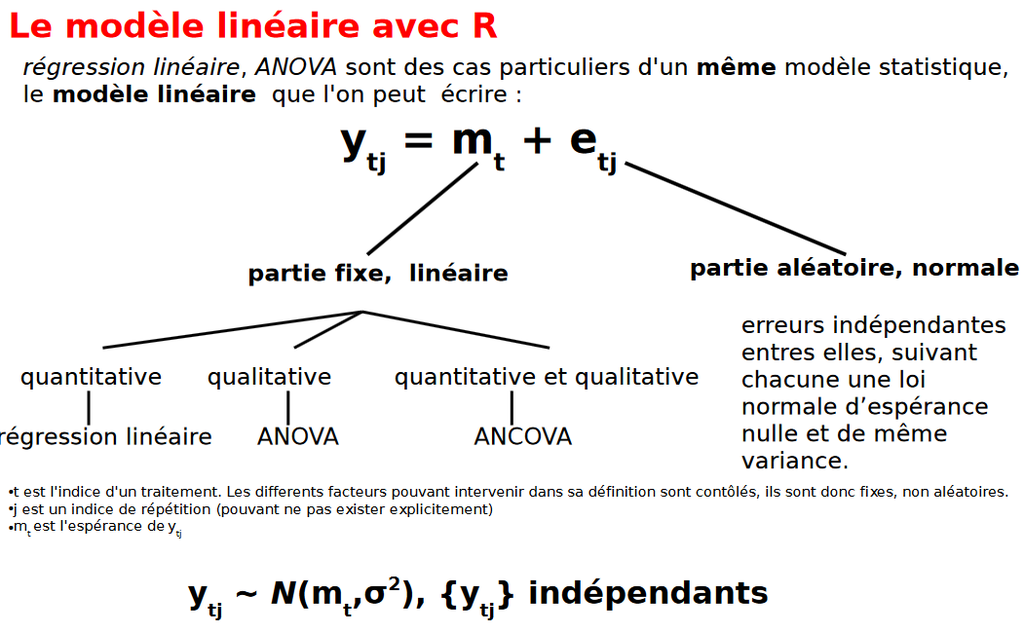

# GLM `[glims]` (d’après *The R Book*)

## Quand ?

Lorsque la variance n’est pas constante, et/ou que les erreurs ne sont pas distribuées selon une loi Normale.

C’est souvent le cas pour des réponses comme :

- les proportions
- les comptages
- les données binaires (mort ou vivant ; succès ou échec)
- les temps de survie / demi-vie

## Une structure des erreurs

Si les erreurs ne suivaient pas une loi Normale, nous avions recours à une transformation. Avec les GLM nous pouvons spécifier le type de distribution des erreurs :

- loi Normale (lm classique)
- loi de Poisson (comptage : y entiers entre 0 et +Inf)
- loi Binomiale (proportions : y entier entre 0 et n cas, 0:1 ou 0:100)
- loi Gamma (y continue entre 0 et +Inf)
- loi Exponentielle (analyse de survie)

Pour spécifier le type de distribution des erreurs, on utilise l’argument `family`.

```r
glm(y ~ z, family = poisson)
```

La variable explicative peut être quantitative continue (analyse de régression), ou qualitative (catégories / facteurs ; analyse de type ANOVA).

## Un prédicteur linéaire

Pour expliquer $y$, nous utilisons une composante déterministe qui nous permet de voir quels sont les prédicteurs ($\beta0+\beta_1x_1+...+\beta_px_p$). Cette combinaison linéaire est appelée prédicteur linéaire et s’exprime avec $\eta$ (eta) :

$$\eta_i=\sum_{j=1}^{p}x_{ij}\beta_j$$

## Fonction de lien

La qualité de l’ajustement des GLM se fait en évaluant le prédicteur linéaire pour chaque valeur de la variable de réponse et le compare à une valeur transformée de y au moyen d’une **fonction de lien**.

Cette fonction de lien est à définir pour chaque cas (minimiser la déviance résiduelle). Pour une première approche on pourra laisser les fonctions de lein par défaut.

# Exemple : données de comptage ~ var qt

## Données de comptage

Loi de Poisson de paramètre lambda ($\lambda$) :

- valeurs entre 0 et +Inf
- $Pr(Y=y)=\frac{e^{−λ}*\lambda^y}{y!}$

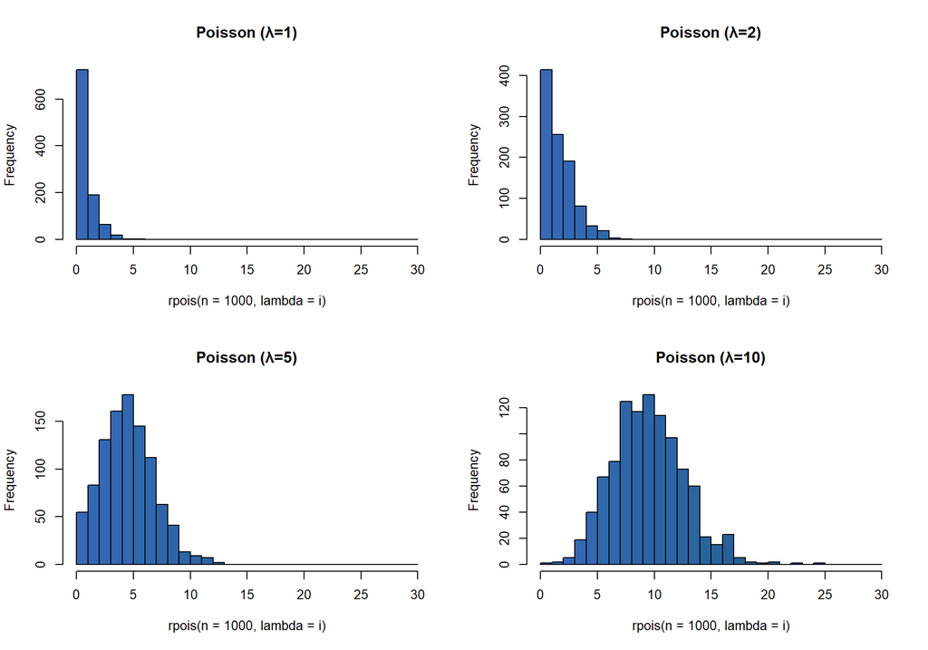

```r
library("palettesForR")
par(mfrow = c(2, 2))
trash <- sapply(c(1, 2, 5, 10), function(i){
  hist(rpois(n = 1000, lambda = i), breaks = 0:30,
    main = paste0("Poisson (\u03BB=", i, ")"),
    col = Dark_gpl)
})
```

## Hypothèses

- réponses indépendantes (sinon => Generalized Linear Mixed Models)
- réponses distribuées selon une loi de Poisson.
- pas de surdispersion

## surdispersion ?

Surdispersion si `residual deviance` > `degrees of freedom`

```r
y <- rpois(n = 1000, lambda = 5)
x <- 1:1000
modSum <- summary(glm(y ~ x, family = "poisson"))
phiEst <- modSum$null.deviance / modSum$df[2]
print(phiEst) # > 1 ?
```

```
## [1] 0.9754727
```

*Les principales cause des surdispersions sont :*

*- une corrélation entre les réponses,*

*- l’absence d’une variable explicative importante,*

*- un sur-représentation des valeurs zéro par rapport à ce qui est attendue selon la distribution de Poissson de paramètre Lambda.*

*En cas de surdispersion, il est nécessaire d’utiliser d’autres structures d’erreur, telles que les structures ‘quasi Poisson’ ou ‘négative binomiale’.* C. Della Vedova

Ici : absence d’une variable explicative importante

```r
# comptage de lynx en fonction des tâches solaires
suns <- as.vector(ts.intersect(lynx, sunspot.year)[,"sunspot.year"])
lynx <- as.vector(ts.intersect(lynx, sunspot.year)[,"lynx"])
modSum <- summary(glm(lynx ~ suns, family = "poisson"))
print(modSum)
```

```
##
## Call:
## glm(formula = lynx ~ suns, family = "poisson")
##
## Deviance Residuals:
##    Min      1Q  Median      3Q     Max
## -51.14  -37.31  -19.95   22.79  101.57
##
## Coefficients:
##              Estimate Std. Error z value Pr(>|z|)
## (Intercept) 7.264e+00  4.016e-03 1808.81   <2e-16 ***
## suns        1.654e-03  7.055e-05   23.44   <2e-16 ***
## ---
## Signif. codes:  0 '***' 0.001 '**' 0.01 '*' 0.05 '.' 0.1 ' ' 1
##
## (Dispersion parameter for poisson family taken to be 1)
##
##     Null deviance: 168370  on 113  degrees of freedom
## Residual deviance: 167827  on 112  degrees of freedom
## AIC: 168803
##
## Number of Fisher Scoring iterations: 5
```

## Hypothèses

Indépendance : oui (sous l’hypothèse que les lynx tués une année n’influencent pas les populations des années suivantes - en tout cas à la fin du XIXème - … )

## Hypothèses

Distribution de Poisson :

```r
mean(lynx)
```

```
## [1] 1538.018
```

```r
distrTheo <- rpois(length(lynx), lambda = mean(lynx))
```

## Hypothèses

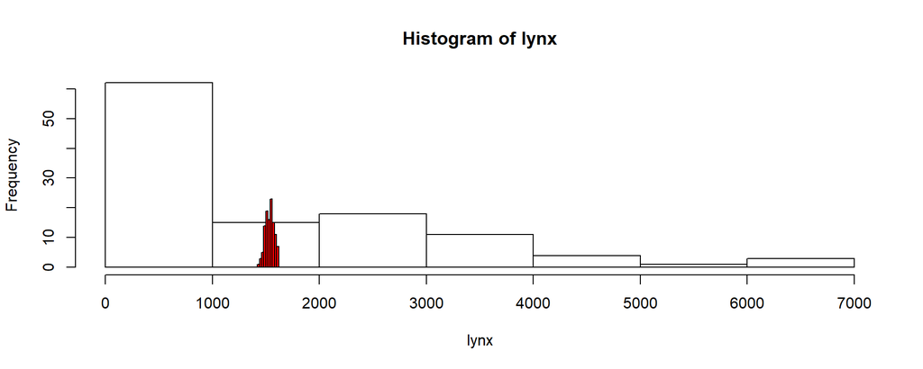

```r
hist(lynx)
hist(distrTheo, col = 2, add = TRUE)
```

## Hypothèses

Distribution de Poisson : non

## Hypothèses

Sudispersion : oui

```r
phiEst <- modSum$null.deviance / modSum$df[2]
print(phiEst) # > 1 ?
```

```
## [1] 1503.3
```

```r
# très forte surdispersion : on change de structure d'erreur
```

## Structure quasipoisson (surdispersion)

```r
modSum <- summary(glm(lynx ~ suns, family = "quasipoisson"))
print(modSum)
```

```
##
## Call:
## glm(formula = lynx ~ suns, family = "quasipoisson")
##
## Deviance Residuals:
##    Min      1Q  Median      3Q     Max
## -51.14  -37.31  -19.95   22.79  101.57
##
## Coefficients:
##             Estimate Std. Error t value Pr(>|t|)
## (Intercept) 7.264107   0.163136  44.528   <2e-16 ***
## suns        0.001654   0.002866   0.577    0.565
## ---
## Signif. codes:  0 '***' 0.001 '**' 0.01 '*' 0.05 '.' 0.1 ' ' 1
##
## (Dispersion parameter for quasipoisson family taken to be 1650.133)
##
##     Null deviance: 168370  on 113  degrees of freedom
## Residual deviance: 167827  on 112  degrees of freedom
## AIC: NA
##
## Number of Fisher Scoring iterations: 5
```

# Exemple : données de comptage ~ var ql

## Données de comptage (dataset depuis Kaggle)

[Nombre de feux au Brésil par état](https://www.kaggle.com/gustavomodelli/forest-fires-in-brazil)

```r
feux <- read.table("./DATA/amazon.csv",
  header = TRUE, sep = ",")
feux$number <- as.integer(feux$number)
library("palettesForR")
```

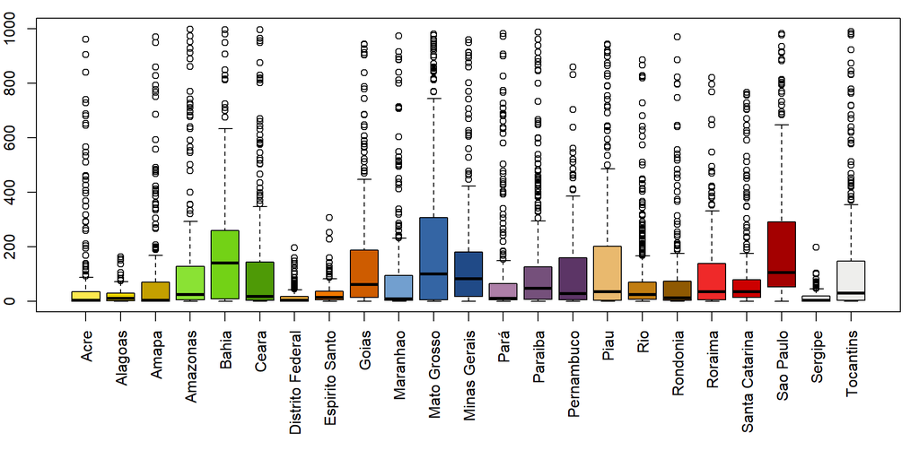

```r
par(mar = c(8, 2, 1, 1))
boxplot(feux$number ~ feux$state,
  las = 3, xlab = "", col = Tango_gpl)
```

```r
tapply(feux$number, INDEX = feux$state, FUN = sum)
```

```
##             Acre          Alagoas            Amapa         Amazonas
##            18452             4644            21831            30636
##            Bahia            Ceara Distrito Federal   Espirito Santo
##            44718            30415             3561             6546
##            Goias         Maranhao      Mato Grosso     Minas Gerais
##            37677            25082            96178            37453
##             Pará          Paraiba       Pernambuco             Piau
##            24459            52432            24498            37777
##              Rio         Rondonia          Roraima   Santa Catarina
##            45160            20259            24384            24359
##        Sao Paulo          Sergipe        Tocantins
##            51118             3237            33675
```

```r
feux$state <- factor(
  feux$state,
  levels(feux$state)[order(
    tapply(feux$number, INDEX = feux$state, FUN = sum))
  ])
```

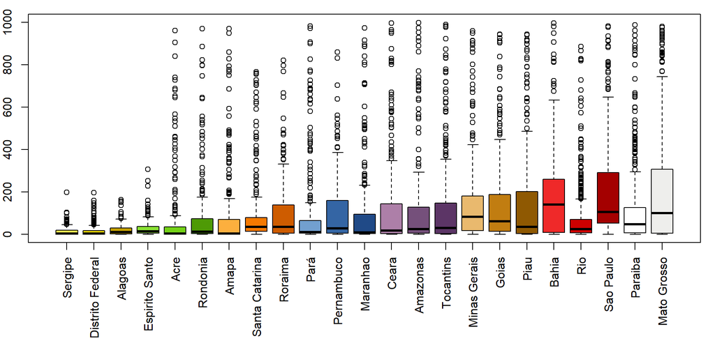

```r
par(mar = c(8, 2, 1, 1))
boxplot(feux$number ~ feux$state,
  las = 3, xlab = "", col = Tango_gpl)
```

```r
tapply(feux$number, INDEX = feux$state, FUN = summary)
```

```
## $Sergipe
##    Min. 1st Qu.  Median    Mean 3rd Qu.    Max.
##    0.00    0.00    3.00   13.54   18.00  198.00
##
## $`Distrito Federal`
##    Min. 1st Qu.  Median    Mean 3rd Qu.    Max.
##     0.0     0.0     2.0    14.9    17.5   196.0
##
## $Alagoas
##    Min. 1st Qu.  Median    Mean 3rd Qu.    Max.
##    0.00    1.00   10.00   19.35   29.00  162.00
##
## $`Espirito Santo`
##    Min. 1st Qu.  Median    Mean 3rd Qu.    Max.
##    0.00    4.50   13.00   27.39   36.00  307.00
##
## $Acre
##    Min. 1st Qu.  Median    Mean 3rd Qu.    Max.
##     0.0     0.0     2.0    77.2    35.0   960.0
##
## $Rondonia
##    Min. 1st Qu.  Median    Mean 3rd Qu.    Max.
##    0.00    3.00   11.00   84.77   72.50  969.00
##
## $Amapa
##    Min. 1st Qu.  Median    Mean 3rd Qu.    Max.
##    0.00    0.00    2.00   91.34   70.00  969.00
##
## $`Santa Catarina`
##    Min. 1st Qu.  Median    Mean 3rd Qu.    Max.
##     0.0    14.0    34.0   101.9    79.0   765.0
##
## $Roraima
##    Min. 1st Qu.  Median    Mean 3rd Qu.    Max.
##       0       4      35     102     137     820
##
## $Pará
##    Min. 1st Qu.  Median    Mean 3rd Qu.    Max.
##     0.0     4.0    10.0   102.3    63.5   982.0
##
```

[output cut: 36 more lines]

```
## $Rio
##    Min. 1st Qu.  Median    Mean 3rd Qu.    Max.
##    0.00    6.00   24.00   62.98   70.00  885.00
##
## $`Sao Paulo`
##    Min. 1st Qu.  Median    Mean 3rd Qu.    Max.
##     0.0    52.0   104.0   213.9   290.0   981.0
##
## $Paraiba
##    Min. 1st Qu.  Median    Mean 3rd Qu.    Max.
##     0.0     6.0    46.0   109.7   125.0   987.0
##
## $`Mato Grosso`
##    Min. 1st Qu.  Median    Mean 3rd Qu.    Max.
##    0.00    5.25  100.00  201.21  305.50  979.00
```

```r
modL <- glm(feux$number ~ feux$state, family = "poisson")
print(modL)
```

```
##
## Call:  glm(formula = feux$number ~ feux$state, family = "poisson")
##
## Coefficients:
##                (Intercept)  feux$stateDistrito Federal
##                    2.60594                     0.09539
##          feux$stateAlagoas    feux$stateEspirito Santo
##                    0.35675                     0.70421
##             feux$stateAcre          feux$stateRondonia
##                    1.74053                     1.83395
##            feux$stateAmapa    feux$stateSanta Catarina
##                    1.90868                     2.01825
##          feux$stateRoraima              feux$statePará
##                    2.01928                     2.02235
##       feux$statePernambuco          feux$stateMaranhao
##                    2.02394                     2.04750
##            feux$stateCeara          feux$stateAmazonas
##                    2.24029                     2.24753
##        feux$stateTocantins      feux$stateMinas Gerais
##                    2.34211                     2.44844
##            feux$stateGoias              feux$statePiau
##                    2.45440                     2.45705
##            feux$stateBahia               feux$stateRio
##                    2.62573                     1.53695
##        feux$stateSao Paulo           feux$stateParaiba
##                    2.75949                     2.09172
##      feux$stateMato Grosso
##                    2.69841
##
## Degrees of Freedom: 6453 Total (i.e. Null);  6431 Residual
## Null Deviance:       1464000
## Residual Deviance: 1255000   AIC: 1285000
```

## Hypothèses

- Indépendance : ok?
- Distrib. poisson ? surdispersion ?

```r
summary(modL)
```

```
##
## Call:
## glm(formula = feux$number ~ feux$state, family = "poisson")
##
## Deviance Residuals:
##     Min       1Q   Median       3Q      Max
## -20.682  -12.572   -6.331    1.396   55.441
##
## Coefficients:
##                            Estimate Std. Error z value Pr(>|z|)
## (Intercept)                 2.60594    0.01758 148.264  < 2e-16 ***
## feux$stateDistrito Federal  0.09539    0.02428   3.928 8.56e-05 ***
## feux$stateAlagoas           0.35675    0.02290  15.581  < 2e-16 ***
## feux$stateEspirito Santo    0.70421    0.02149  32.774  < 2e-16 ***
## feux$stateAcre              1.74053    0.01906  91.341  < 2e-16 ***
## feux$stateRondonia          1.83395    0.01893  96.889  < 2e-16 ***
## feux$stateAmapa             1.90868    0.01883 101.341  < 2e-16 ***
## feux$stateSanta Catarina    2.01825    0.01871 107.883  < 2e-16 ***
## feux$stateRoraima           2.01928    0.01871 107.945  < 2e-16 ***
## feux$statePará              2.02235    0.01870 108.128  < 2e-16 ***
## feux$statePernambuco        2.02394    0.01870 108.223  < 2e-16 ***
## feux$stateMaranhao          2.04750    0.01868 109.632  < 2e-16 ***
## feux$stateCeara             2.24029    0.01849 121.175  < 2e-16 ***
## feux$stateAmazonas          2.24753    0.01848 121.609  < 2e-16 ***
## feux$stateTocantins         2.34211    0.01840 127.277  < 2e-16 ***
## feux$stateMinas Gerais      2.44844    0.01832 133.647  < 2e-16 ***
## feux$stateGoias             2.45440    0.01832 134.005  < 2e-16 ***
## feux$statePiau              2.45705    0.01831 134.163  < 2e-16 ***
## feux$stateBahia             2.62573    0.01820 144.260  < 2e-16 ***
## feux$stateRio               1.53695    0.01820  84.469  < 2e-16 ***
## feux$stateSao Paulo         2.75949    0.01812 152.254  < 2e-16 ***
## feux$stateParaiba           2.09172    0.01811 115.496  < 2e-16 ***
## feux$stateMato Grosso       2.69841    0.01787 151.005  < 2e-16 ***
## ---
## Signif. codes:  0 '***' 0.001 '**' 0.01 '*' 0.05 '.' 0.1 ' ' 1
##
## (Dispersion parameter for poisson family taken to be 1)
##
##     Null deviance: 1463651  on 6453  degrees of freedom
## Residual deviance: 1254755  on 6431  degrees of freedom
## AIC: 1285112
##
## Number of Fisher Scoring iterations: 6
```

Le ratio residual deviance / ddl est égal à 1254755 / 6431 = 195. Beaucoup de surdispersion ! Il est nécessaire d’utiliser une autre structure d’erreur.

```r
modL <- glm(feux$number ~ feux$state, family = "quasipoisson")
summary(modL)
```

```
##
## Call:
## glm(formula = feux$number ~ feux$state, family = "quasipoisson")
##
## Deviance Residuals:
##     Min       1Q   Median       3Q      Max
## -20.682  -12.572   -6.331    1.396   55.441
##
## Coefficients:
##                            Estimate Std. Error t value Pr(>|t|)
## (Intercept)                 2.60594    0.29133   8.945  < 2e-16 ***
## feux$stateDistrito Federal  0.09539    0.40251   0.237    0.813
## feux$stateAlagoas           0.35675    0.37951   0.940    0.347
## feux$stateEspirito Santo    0.70421    0.35614   1.977    0.048 *
## feux$stateAcre              1.74053    0.31584   5.511 3.71e-08 ***
## feux$stateRondonia          1.83395    0.31374   5.846 5.30e-09 ***
## feux$stateAmapa             1.90868    0.31218   6.114 1.03e-09 ***
## feux$stateSanta Catarina    2.01825    0.31008   6.509 8.14e-11 ***
## feux$stateRoraima           2.01928    0.31006   6.513 7.95e-11 ***
## feux$statePará              2.02235    0.31000   6.524 7.38e-11 ***
## feux$statePernambuco        2.02394    0.30997   6.529 7.11e-11 ***
## feux$stateMaranhao          2.04750    0.30955   6.614 4.03e-11 ***
## feux$stateCeara             2.24029    0.30644   7.311 2.98e-13 ***
## feux$stateAmazonas          2.24753    0.30633   7.337 2.45e-13 ***
## feux$stateTocantins         2.34211    0.30501   7.679 1.84e-14 ***
## feux$stateMinas Gerais      2.44844    0.30365   8.063 8.79e-16 ***
## feux$stateGoias             2.45440    0.30358   8.085 7.38e-16 ***
## feux$statePiau              2.45705    0.30355   8.094 6.83e-16 ***
## feux$stateBahia             2.62573    0.30168   8.704  < 2e-16 ***
## feux$stateRio               1.53695    0.30159   5.096 3.56e-07 ***
## feux$stateSao Paulo         2.75949    0.30041   9.186  < 2e-16 ***
## feux$stateParaiba           2.09172    0.30018   6.968 3.53e-12 ***
## feux$stateMato Grosso       2.69841    0.29619   9.110  < 2e-16 ***
## ---
## Signif. codes:  0 '***' 0.001 '**' 0.01 '*' 0.05 '.' 0.1 ' ' 1
##
## (Dispersion parameter for quasipoisson family taken to be 274.7254)
##
##     Null deviance: 1463651  on 6453  degrees of freedom
## Residual deviance: 1254755  on 6431  degrees of freedom
## AIC: NA
##
## Number of Fisher Scoring iterations: 6
```

## Interprétation

Table de variance (cas surdispersion avec Fisher) :

```r
library("car")
Anova(modL, test.statistic = "F")
```

```
## Analysis of Deviance Table (Type II tests)
##
## Response: feux$number
## Error estimate based on Pearson residuals
##
##             Sum Sq   Df F value    Pr(>F)
## feux$state  208896   22  34.564 < 2.2e-16 ***
## Residuals  1766701 6431
## ---
## Signif. codes:  0 '***' 0.001 '**' 0.01 '*' 0.05 '.' 0.1 ' ' 1
```

## Comp. multiples

```r
library(multcomp)
modL <- glm(number ~ state, family = "quasipoisson", data = feux)
tuk <- glht(modL, linfct = mcp(state = "Tukey"))
summary(tuk)
```

```
##
##   Simultaneous Tests for General Linear Hypotheses
##
## Multiple Comparisons of Means: Tukey Contrasts
##
##
## Fit: glm(formula = number ~ state, family = "quasipoisson", data = feux)
##
## Linear Hypotheses:
##                                         Estimate Std. Error z value
## Distrito Federal - Sergipe == 0         0.095394   0.402514   0.237
## Alagoas - Sergipe == 0                  0.356754   0.379509   0.940
## Espirito Santo - Sergipe == 0           0.704207   0.356144   1.977
## Acre - Sergipe == 0                     1.740526   0.315837   5.511
## Rondonia - Sergipe == 0                 1.833952   0.313737   5.846
## Amapa - Sergipe == 0                    1.908684   0.312175   6.114
## Santa Catarina - Sergipe == 0           2.018254   0.310078   6.509
## Roraima - Sergipe == 0                  2.019280   0.310060   6.513
## Pará - Sergipe == 0                     2.022351   0.310003   6.524
## Pernambuco - Sergipe == 0               2.023945   0.309975   6.529
## Maranhao - Sergipe == 0                 2.047503   0.309553   6.614
## Ceara - Sergipe == 0                    2.240289   0.306436   7.311
## Amazonas - Sergipe == 0                 2.247529   0.306329   7.337
## Tocantins - Sergipe == 0                2.342109   0.305006   7.679
## Minas Gerais - Sergipe == 0             2.448440   0.303654   8.063
## Goias - Sergipe == 0                    2.454403   0.303582   8.085
## Piau - Sergipe == 0                     2.457053   0.303550   8.094
## Bahia - Sergipe == 0                    2.625729   0.301685   8.704
## Rio - Sergipe == 0                      1.536952   0.301585   5.096
## Sao Paulo - Sergipe == 0                2.759490   0.300407   9.186
## Paraiba - Sergipe == 0                  2.091723   0.300183   6.968
## Mato Grosso - Sergipe == 0              2.698406   0.296187   9.110
## Alagoas - Distrito Federal == 0         0.261359   0.369194   0.708
## Espirito Santo - Distrito Federal == 0  0.608813   0.345131   1.764
## Acre - Distrito Federal == 0            1.645131   0.303364   5.423
## Rondonia - Distrito Federal == 0        1.738558   0.301177   5.773
## Amapa - Distrito Federal == 0           1.813290   0.299550   6.053
## Santa Catarina - Distrito Federal == 0  1.922860   0.297364   6.466
## Roraima - Distrito Federal == 0         1.923886   0.297345   6.470
## Pará - Distrito Federal == 0            1.926957   0.297286   6.482
```

[output cut: 465 more lines]

```
## Paraiba - Piau == 0                      0.1247
## Mato Grosso - Piau == 0                  0.6940
## Rio - Bahia == 0                          <0.01 ***
## Sao Paulo - Bahia == 0                   0.9998
## Paraiba - Bahia == 0                      <0.01 ***
## Mato Grosso - Bahia == 0                 1.0000
## Sao Paulo - Rio == 0                      <0.01 ***
## Paraiba - Rio == 0                        <0.01 ***
## Mato Grosso - Rio == 0                    <0.01 ***
## Paraiba - Sao Paulo == 0                  <0.01 ***
## Mato Grosso - Sao Paulo == 0             1.0000
## Mato Grosso - Paraiba == 0                <0.01 ***
## ---
## Signif. codes:  0 '***' 0.001 '**' 0.01 '*' 0.05 '.' 0.1 ' ' 1
## (Adjusted p values reported -- single-step method)
```

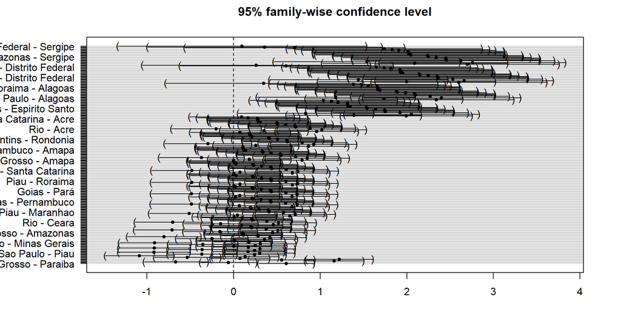

```r
par(mar=c(3, 7, 3, 3))
plot(tuk)
```

```r
tukLetters <- cld(tuk)
tL <- tukLetters$mcletters$Letters
tLdf <- data.frame(
  state = levels(feux$state),
  letters = tL)
```

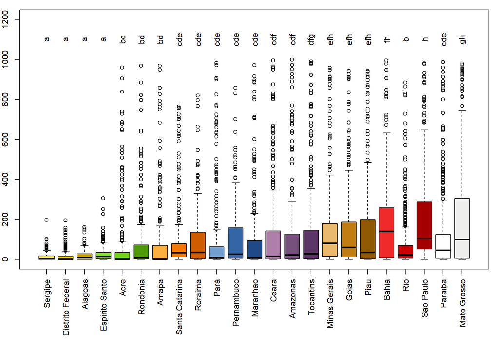

```r
par(mar = c(8, 2, 1, 1))
boxplot(feux$number ~ feux$state, ylim = c(0, 1200),
  las = 3, xlab = "", col = Tango_gpl)
text(x = 1:length(levels(feux$state)),
  y = rep(1100, length(levels(feux$state))),
  labels = tLdf$letters, srt = 90)
```

## pour aller plus loin…

The legal Amazon comprises the states of Acre, Amapá, Pará, Amazonas, Rondonia, Roraima, and part of Mato Grosso, Tocantins, and Maranhão.

# Exemple : données de type catégoriel binaire

## Données de type catégoriel binaire (dataset depuis Kaggle)

On parle de *régression logistique*.

[Medical Cost Personal Datasets](https://www.kaggle.com/mirichoi0218/insurance/)

```r
secu <- read.table("./DATA/insurance.csv",
  header = TRUE, sep = ",")
```

La proba. de fumer peut-elle s’expliquer par l’âge ?

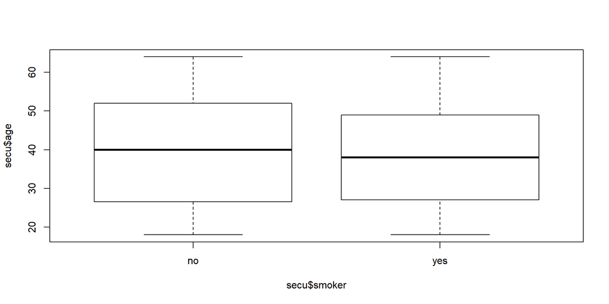

```r
boxplot(secu$age ~ secu$smoker)
```

```r
secu$smoker <- as.character(secu$smoker)
secu$smoker[secu$smoker == "yes"] <- 1
secu$smoker[secu$smoker == "no"] <- 0
secu$smoker <- as.logical(as.numeric(secu$smoker))
```

## Age ?

```r
secu$ageT <- cut(secu$age, breaks = seq(from = 0, to = 100, by = 5))
```

## Age ?

```r
ni <- tapply(secu$smoker, INDEX = secu$ageT, FUN = length)
nT <- tapply(secu$smoker, INDEX = secu$ageT, FUN = sum)
nProp <- nT/ni
xT <- seq(from = 2.5, to = 97.5, by = 5)
dfSmoke <- data.frame(xT, nProp, nT, ni)
```

## Age ?

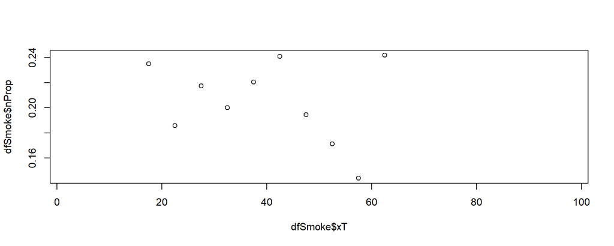

```r
plot(dfSmoke$nProp ~ dfSmoke$xT)
```

## Age ?

```r
summary(glm(secu$smoker ~ secu$age, family = "binomial"))
```

```
##
## Call:
## glm(formula = secu$smoker ~ secu$age, family = "binomial")
##
## Deviance Residuals:
##     Min       1Q   Median       3Q      Max
## -0.7054  -0.6890  -0.6676  -0.6480   1.8302
##
## Coefficients:
##              Estimate Std. Error z value Pr(>|z|)
## (Intercept) -1.184440   0.198907  -5.955  2.6e-09 ***
## secu$age    -0.004422   0.004833  -0.915     0.36
## ---
## Signif. codes:  0 '***' 0.001 '**' 0.01 '*' 0.05 '.' 0.1 ' ' 1
##
## (Dispersion parameter for binomial family taken to be 1)
##
##     Null deviance: 1356.6  on 1337  degrees of freedom
## Residual deviance: 1355.8  on 1336  degrees of freedom
## AIC: 1359.8
##
## Number of Fisher Scoring iterations: 4
```

## Charges ?

Est-ce que le montant des charges de santé permet de prédire la proba de fumer ?

```r
secu$chargesT <- cut(secu$charges, breaks = seq(from = 0, to = 70000, by = 5000))
ni <- tapply(secu$smoker, INDEX = secu$chargesT, FUN = length)
nT <- tapply(secu$smoker, INDEX = secu$chargesT, FUN = sum)
nProp <- nT/ni
xT <- seq(from = 2500, to = 67500, by = 5000)
dfCharges <- data.frame(xT, nProp, nT, ni)
```

## Charges ?

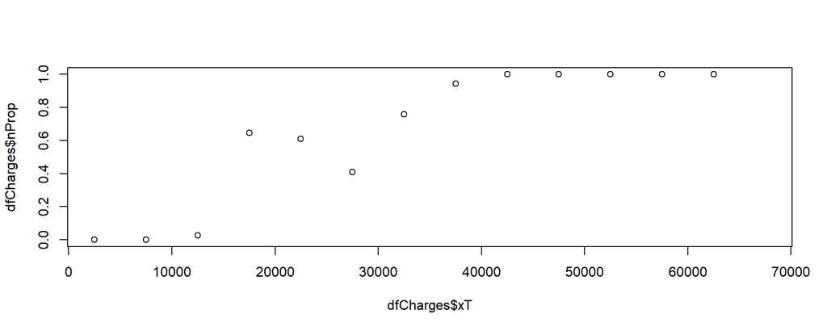

```r
plot(dfCharges$nProp ~ dfCharges$xT)
```

## Charges ?

```r
modL <- glm(secu$smoker ~ secu$charges, family = "binomial")
summary(modL)
```

```
##
## Call:
## glm(formula = secu$smoker ~ secu$charges, family = "binomial")
##
## Deviance Residuals:
##     Min       1Q   Median       3Q      Max
## -2.7137  -0.2990  -0.1623  -0.1018   2.2494
##
## Coefficients:
##                Estimate Std. Error z value Pr(>|z|)
## (Intercept)  -5.698e+00  3.064e-01  -18.60   <2e-16 ***
## secu$charges  2.535e-04  1.593e-05   15.91   <2e-16 ***
## ---
## Signif. codes:  0 '***' 0.001 '**' 0.01 '*' 0.05 '.' 0.1 ' ' 1
##
## (Dispersion parameter for binomial family taken to be 1)
##
##     Null deviance: 1356.63  on 1337  degrees of freedom
## Residual deviance:  503.65  on 1336  degrees of freedom
## AIC: 507.65
##
## Number of Fisher Scoring iterations: 6
```

## Charges ?

```r
beta0 <- coef(modL)[1]
beta1 <- coef(modL)[2]
axeX <- seq(from = 0, to = 70000, length.out = 1000)
```

## Charges ?

```r
plot(
  x = dfCharges$xT,
  y = dfCharges$nProp,
  col = 'red', lwd = 3, xlim = c(0, 70000),
  ylim = c(0, 1), xlab = "Charges", ylab = "Proba(smoke)")
lines(
  axeX,
  plogis(beta0 + beta1*axeX) , col='blue' , lwd = 4, lty = 3)
legend("topleft", c("obs", "logit"), lwd = 3, col = c("red", "blue"))
```

## Charges ?

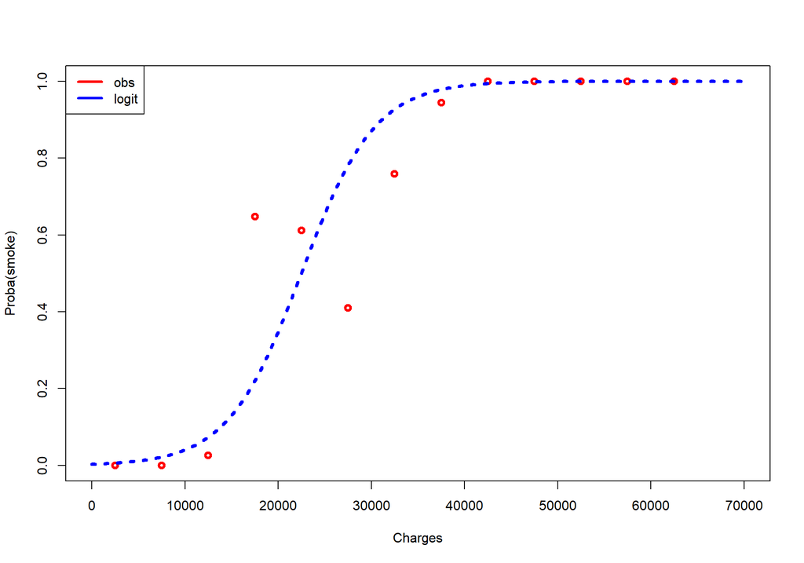

# Exemple : données de type catégoriel binaire (2)

## Données de type catégoriel binaire (d’après cours E. Paradis)

## Dataset : AIDS in australia

```r
library(MASS)
data(Aids2)
```

- state: Grouped state of origin: “NSW”includes ACT and “other” is WA, SA, NT and TAS.
- sex: Sex of patient.
- diag: (Julian) date of diagnosis.
- death: (Julian) date of death or end of observation.
- status: “A” (alive) or “D” (dead) at end of observation.
- T.categ: Reported transmission category.
- age: Age (years) at diagnosis.

On va essayer d’expliquer le statut à la fin des observations.

## genre ?

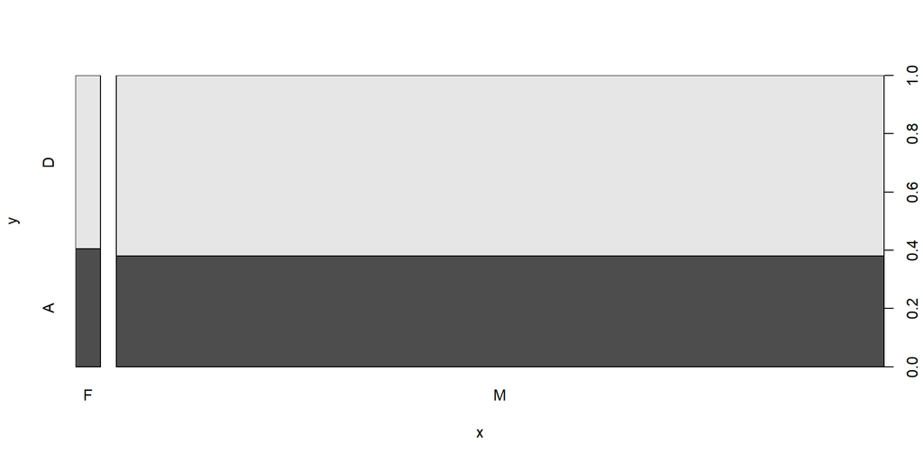

```r
plot(y = Aids2$status, x = Aids2$sex)
```

## genre ?

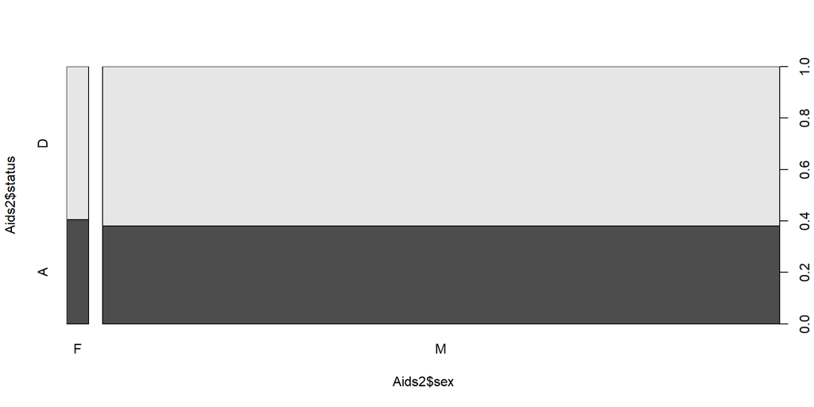

```r
plot(Aids2$status ~ Aids2$sex)
```

## genre ?

```r
modL01 <- glm(status ~ sex, family = "binomial", data = Aids2)
summary(modL01)
```

```
##
## Call:
## glm(formula = status ~ sex, family = "binomial", data = Aids2)
##
## Deviance Residuals:
##     Min       1Q   Median       3Q      Max
## -1.3915  -1.3915   0.9775   0.9775   1.0182
##
## Coefficients:
##             Estimate Std. Error z value Pr(>|z|)
## (Intercept)   0.3868     0.2160   1.791   0.0733 .
## sexM          0.1036     0.2195   0.472   0.6370
## ---
## Signif. codes:  0 '***' 0.001 '**' 0.01 '*' 0.05 '.' 0.1 ' ' 1
##
## (Dispersion parameter for binomial family taken to be 1)
##
##     Null deviance: 3777.5  on 2842  degrees of freedom
## Residual deviance: 3777.3  on 2841  degrees of freedom
## AIC: 3781.3
##
## Number of Fisher Scoring iterations: 4
```

## âge ?

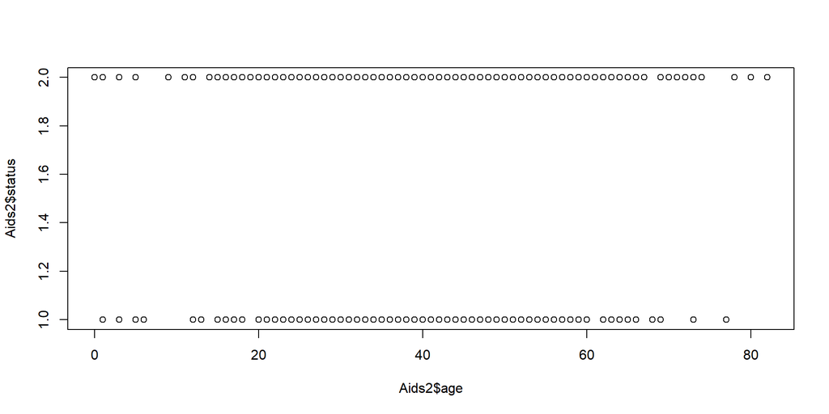

```r
plot(y = Aids2$status, x = Aids2$age)
```

## âge ?

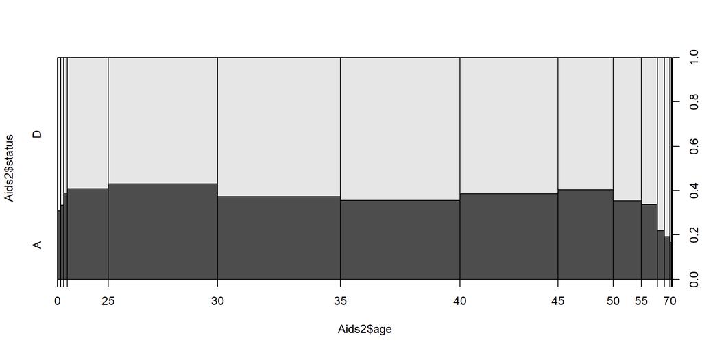

```r
plot(Aids2$status ~ Aids2$age)
```

## âge ?

```r
modL02 <- glm(status ~ age, family = "binomial", data = Aids2)
summary(modL02)
```

```
##
## Call:
## glm(formula = status ~ age, family = "binomial", data = Aids2)
##
## Deviance Residuals:
##     Min       1Q   Median       3Q      Max
## -1.5696  -1.3663   0.9450   0.9917   1.1303
##
## Coefficients:
##             Estimate Std. Error z value Pr(>|z|)
## (Intercept) 0.111819   0.149300   0.749   0.4539
## age         0.010065   0.003881   2.593   0.0095 **
## ---
## Signif. codes:  0 '***' 0.001 '**' 0.01 '*' 0.05 '.' 0.1 ' ' 1
##
## (Dispersion parameter for binomial family taken to be 1)
##
##     Null deviance: 3777.5  on 2842  degrees of freedom
## Residual deviance: 3770.7  on 2841  degrees of freedom
## AIC: 3774.7
##
## Number of Fisher Scoring iterations: 4
```

## âge ?

```r
Aids2$ageT <- cut(Aids2$age, breaks = seq(from = 0, to = 100, by = 10))
ni <- tapply(as.numeric(Aids2$status)-1, INDEX = Aids2$ageT, FUN = length)
nT <- tapply(as.numeric(Aids2$status)-1, INDEX = Aids2$ageT, FUN = sum)
nProp <- nT/ni
xT <- seq(from = 5, to = 95, by = 10)
dfage <- data.frame(xT, nProp, nT, ni)
modL <- modL02
```

## âge ?

```r
plot(
  x = dfage$xT,
  y = dfage$nProp,
  col = 'red', lwd = 3, xlim = c(0, 100),
  ylim = c(0, 1), xlab = "âge", ylab = "Proba(death)")

lines(
  x = seq(from = 0, to = 100, by = 10),
  y = predict(modL, list(
    age = seq(from = 0, to = 100, by = 10)),
    type = "response"),
  col = 'blue', lwd = 4, lty = 3)
legend("topleft", c("obs", "logit"), lwd = 3, col = c("red", "blue"))
```

## âge ?

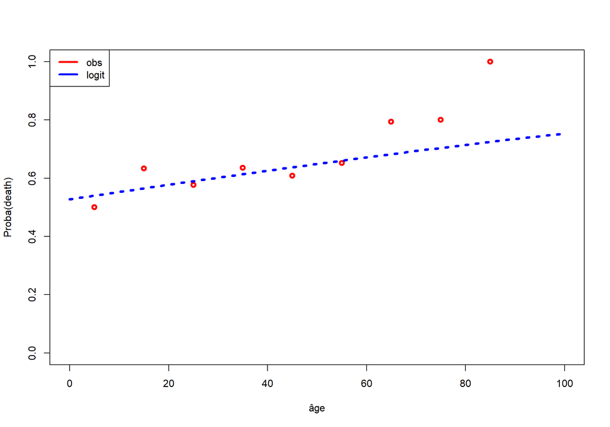

## âge et genre ?

```r
modL03 <- glm(status ~ age*sex, family = "binomial", data = Aids2)
summary(modL03)
```

```
##
## Call:
## glm(formula = status ~ age * sex, family = "binomial", data = Aids2)
##
## Deviance Residuals:
##     Min       1Q   Median       3Q      Max
## -1.8256  -1.3734   0.9517   0.9873   1.5777
##
## Coefficients:
##             Estimate Std. Error z value Pr(>|z|)
## (Intercept) -0.90485    0.54783  -1.652   0.0986 .
## age          0.03473    0.01383   2.512   0.0120 *
## sexM         1.10907    0.56968   1.947   0.0516 .
## age:sexM    -0.02706    0.01441  -1.878   0.0604 .
## ---
## Signif. codes:  0 '***' 0.001 '**' 0.01 '*' 0.05 '.' 0.1 ' ' 1
##
## (Dispersion parameter for binomial family taken to be 1)
##
##     Null deviance: 3777.5  on 2842  degrees of freedom
## Residual deviance: 3766.6  on 2839  degrees of freedom
## AIC: 3774.6
##
## Number of Fisher Scoring iterations: 4
```

## âge et genre ?

```r
AIC(modL01)
```

```
## [1] 3781.269
```

```r
AIC(modL02)
```

```
## [1] 3774.705
```

```r
AIC(modL03)
```

```
## [1] 3774.648
```

On garde le modèle `modL02`.

# Exemple : données de type gamma [0 ; +Inf]

## Données de temps de survie (d’après cours E. Paradis)

Survie en jours = date mort - date diagnostic

```r
Aids2$surv <- Aids2$death - Aids2$diag
```

## âge ?

```r
modLS01 <- glm(surv ~ age, family = "Gamma",
  data = Aids2, subset = surv > 0)
summary(modLS01)
```

```
##
## Call:
## glm(formula = surv ~ age, family = "Gamma", data = Aids2, subset = surv >
##     0)
##
## Deviance Residuals:
##     Min       1Q   Median       3Q      Max
## -3.2565  -0.9426  -0.2280   0.3740   3.0442
##
## Coefficients:
##              Estimate Std. Error t value Pr(>|t|)
## (Intercept) 1.539e-03  1.543e-04   9.969  < 2e-16 ***
## age         2.471e-05  4.199e-06   5.884 4.47e-09 ***
## ---
## Signif. codes:  0 '***' 0.001 '**' 0.01 '*' 0.05 '.' 0.1 ' ' 1
##
## (Dispersion parameter for Gamma family taken to be 0.7935563)
##
##     Null deviance: 3219.5  on 2813  degrees of freedom
## Residual deviance: 3192.0  on 2812  degrees of freedom
## AIC: 39502
##
## Number of Fisher Scoring iterations: 6
```